# Lab5

Laura Lázaro Soraluce

2025-03-26

### Implementation in R: The case of known derivative

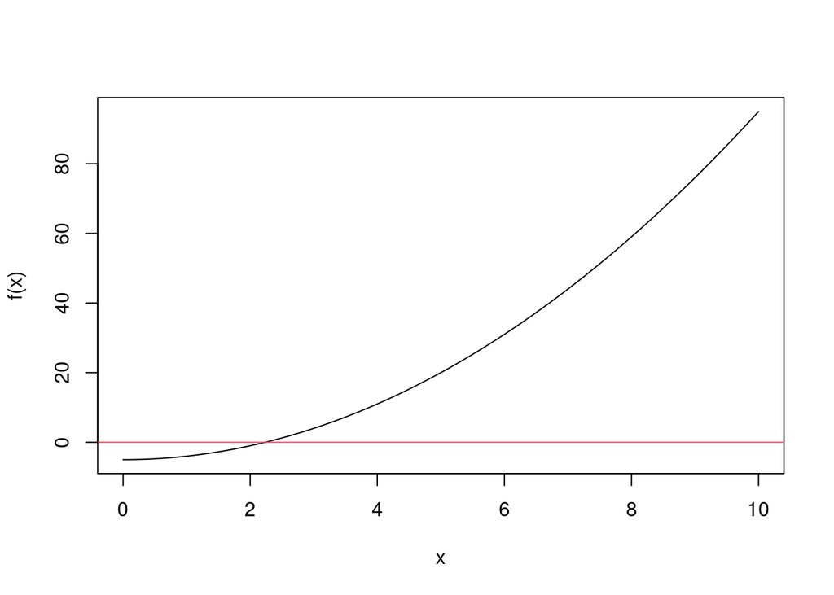

```r
f<-function(x) x^2-5
curve(f,0,10)
abline(h=0, col=2)
```

```r
df<-function(x) 2*x
x0<-2
x1<-x0-f(x0)/df(x0); x1 #First iteration
```

```
## [1] 2.25
```

```r
x2<-x1-f(x1)/df(x1); x2 #Second iteration
```

```
## [1] 2.236111
```

```r
x3<-x2-f(x2)/df(x2); x3 #Third iteration
```

```
## [1] 2.236068
```

```r
x4<-x3-f(x3)/df(x3); x4 #Fourth iteration
```

```
## [1] 2.236068
```

```r
x5<-x4-f(x4)/df(x4); x5 #Fifth iteration
```

```
## [1] 2.236068
```

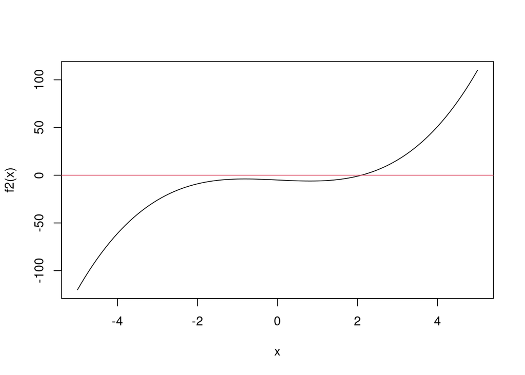

```r
# Function that computes the desired n values
newton_r<-function(x0, f, df, n) {
  x<-numeric(n)
  x<-x0
  for(i in 2:(n+1)) {
    x[i]<-x[i-1]-f(x[i-1])/df(x[i-1])
  }
  return (x)
}

#f(x)=x^3-2x-5
f2<-function(x) x^3-2*x-5
curve(f2,-5,5)
abline(h=0,col=2)
```

##### We can see in the curve that the root is close to 2, so we use that as the initial value

```r
# We compute a few iterations
df2<-function(x) 3*x^2-2
newton_r(2, f2, df2, 5)
```

```
## [1] 2.000000 2.100000 2.094568 2.094551 2.094551 2.094551
```

##### Once again, we can see that it reaches the root by the third iteration

```r
# We try with a poor initial value
newton_r(0, f2, df2, 5)
```

```
## [1]  0.0000000 -2.5000000 -1.5671642 -0.5025924 -3.8207065 -2.5493934
```

```r
# Let's add a few more iterations
newton_r(0, f2, df2, 10)
```

```
##  [1]  0.0000000 -2.5000000 -1.5671642 -0.5025924 -3.8207065 -2.5493934
##  [7] -1.6081115 -0.5761004 -4.5977096 -3.0835431 -2.0221943
```

##### Even if we add a few more iterations, it diverges, as the values move up and down, but nowhere around the real value

```r
# Let's try a different initial value
newton_r(-3, f2, df2, 7)
```

```
## [1] -3.000000 -1.960000 -1.056093  1.964503  2.105188  2.094615  2.094551
## [8]  2.094551
```

```r
newton_r(4, f2, df2, 7)
```

```
## [1] 4.000000 2.891304 2.311223 2.117035 2.094831 2.094552 2.094551 2.094551
```

##### I had already implemented a function, so I’ll adapt it to what the worksheet says

```r
NR<-function(x0, f, df, nmax=50, tol=1e-3) {
  x<-x0
  i<-0

  while(i<nmax){

    if (df(x)==0){
      stop("Derivative is 0")
    }
    xnew<-x-f(x)/df(x)

    final.diff = abs(xnew - x)
    if(final.diff<tol){
      return (list(root = xnew, final.diff, niter=i+1))
    }

    x<-xnew
    i<-i+1
  }

  warning("Max number of iterations reached without converging")
  return (list(root = xnew, final.diff, niter=nmax))
}

NR(2,f,df)
```

```
## $root
## [1] 2.236068
##
## [[2]]
## [1] 4.31332e-05
##
## $niter
## [1] 3
```

```r
NR(2,f2,df2)
```

```
## $root
## [1] 2.094551
##
## [[2]]
## [1] 1.663941e-05
##
## $niter
## [1] 3
```

##### As we can see, the new function works perfectly

### Implementarion using numerical differentiation

```r
library(numDeriv)

f<-function(x) x^2-5
res<-genD(func=f, x=2)
res$D[1]
```

```
## [1] 4
```

```r
x0<-2
x1<-x0-f(x0)/genD(func=f,x=x0)$D[1]; x1
```

```
## [1] 2.25
```

```r
NR2<-function(x0, f, df, nmax=50, tol=1e-5) {
  x<-x0
  i<-0

  while(i<nmax){
    if(missing(df)){
      deriv<-genD(func=f, x=x)$D[1]
      xnew<-x-f(x)/deriv
    }
    else {
      if (df(x)==0){
        stop("Derivative is 0")
      }
      xnew<-x-f(x)/df(x)
    }
    final.diff = abs(xnew - x)
    if(final.diff<tol){
      return (list(root = xnew, final.diff, niter=i+1))
    }

    x<-xnew
    i<-i+1
  }

  warning("Max number of iterations reached without converging")
  return (list(root = xnew, final.diff, niter=nmax))
}

NR2(2, f)
```

```
## $root
## [1] 2.236068
##
## [[2]]
## [1] 4.160139e-10
##
## $niter
## [1] 4
```

```r
NR2(2, f2)
```

```
## $root
## [1] 2.094551
##
## [[2]]
## [1] 1.558731e-10
##
## $niter
## [1] 4
```

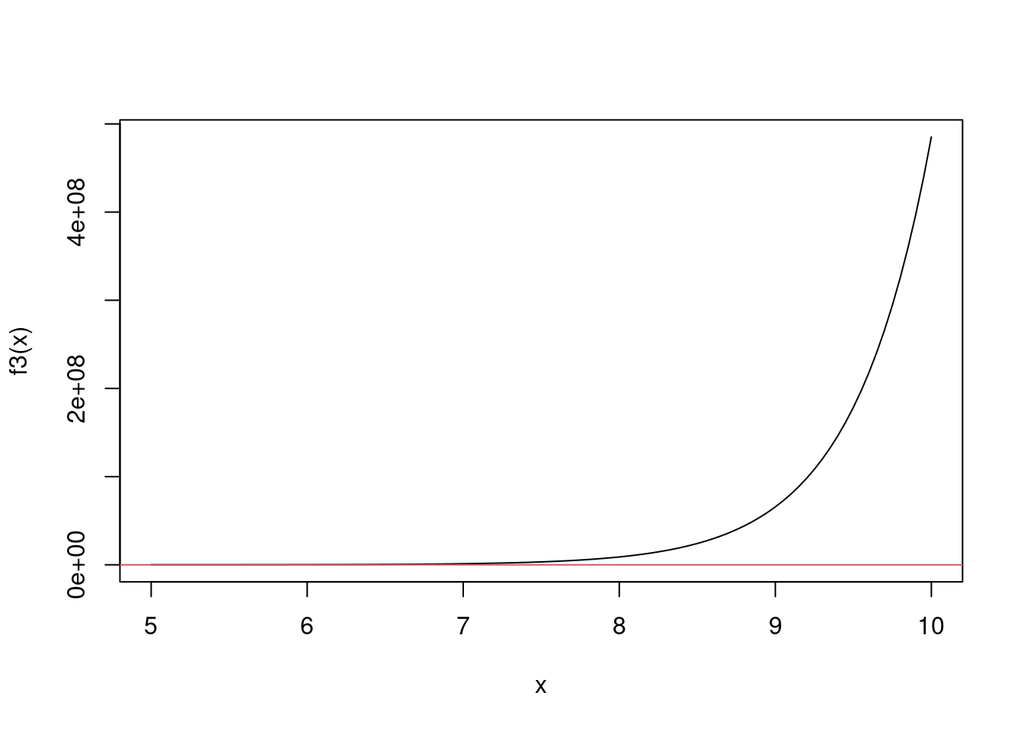

```r
f3<-function(x) (exp(2*x)-x-6)
curve(f3,5,10)
abline(h=0,col=2)
```

```r
NR2(8,f3)
```

```
## $root
## [1] 0.97087
##
## [[2]]
## [1] 7.112267e-10
##
## $niter
## [1] 19
```

```r
uniroot(f, c(0,4), tol=1e-5)$root
```

```
## [1] 2.236068
```

```r
uniroot(f2, c(0,4), tol=1e-5)$root
```

```
## [1] 2.094552
```

```r
uniroot(f3, c(0,4), tol=1e-5)$root
```

```
## [1] 0.97087
```

##### We obtain almost the same results, just a tiny difference in the last decimals.

```r
find_root<-function(f, a0, b0, nmax=100, tol=1e-5){
  i<-1
  a<-a0
  b<-b0
  while (i<nmax){
    r<-a+((b-a)/2)
    if (f(r)==0 || ((b-a)/2)<tol ){
      return(list(root=r, niter=i))
    }
    i<-i+1
    if((f(a)*f(r))>0){
      a=r
    }
    else {
      b=r
    }
  }
  warning("Max number of iterations reached without converging")
  return (list(root = r, niter=nmax))
}

f4<-function(x) x^3+4*x^2-10

# Find_root
find_root(f4, 1, 2)
```

```
## $root
## [1] 1.365227
##
## $niter
## [1] 17
```

```r
# Uniroot
uniroot(f4, c(1,2), tol=1e-5)$root
```

```
## [1] 1.365228
```

```r
# NR2
NR2(1.5, f4)
```

```
## $root
## [1] 1.36523
##
## [[2]]
## [1] 5.020497e-10
##
## $niter
## [1] 4
```

##### The results we get using these 3 functions are basically the same, they just differ in the last decimal. However, the number of iterations until the root value is obtained, is different for the methods find_root and NR2, being a lot smaller for this last one.